# Developing an Image Classifier

In this project, I'll train an image classifier to recognize different species of flowers. To train this classifier, I'll be using [this dataset](http://www.robots.ox.ac.uk/~vgg/data/flowers/102/index.html) of 102 flower categories. Here are a few examples below.

[figure not shown]

The project is broken down into multiple steps:

- Load and preprocess the image dataset
- Train the image classifier on my dataset
- Use the trained classifier to predict image content

When I complete this project, I'll have an application that can be trained on any set of labeled images. Here my network will be learning about flowers and end up as a command line application.

```python
# Import all packages here
import numpy as np
import pandas as pd
import matplotlib.pyplot as plt
% matplotlib inline
%config InlineBackend.figure_format = 'retina'

import torch
from torch import nn, optim
import torch.nn.functional as F
from torchvision import datasets, transforms, models
import torch.utils.data

from PIL import Image
from os import listdir
```

## Load the data

Here I'll use `torchvision` to load the data. The dataset is split into three parts, training, validation, and testing. For the training, I'll apply transformations such as random scaling, cropping, and flipping. This will help the network generalize leading to better performance. I'll make sure the input data is resized to 224x224 pixels as required by the pre-trained networks.

The validation and testing sets are used to measure the model's performance on data that it hasn't seen yet. For this I don't want any scaling or rotation transformations, but I'll resize then crop the images to the appropriate size.

The pre-trained networks I'll use were trained on the ImageNet dataset where each color channel was normalized separately. For all three sets I'll normalize the means and standard deviations of the images to what the network expects. For the means, it's `[0.485, 0.456, 0.406]` and for the standard deviations `[0.229, 0.224, 0.225]`, calculated from the ImageNet images. These values will shift each color channel to be centered at 0 and range from -1 to 1.

```python
data_dir = 'flowers'
train_dir = data_dir + '/train'
valid_dir = data_dir + '/valid'
test_dir = data_dir + '/test'
```

```python
# Define transforms for the training, validation, and testing sets
data_transforms = {'train': transforms.Compose([transforms.RandomRotation(30),
                                                transforms.RandomResizedCrop(224),
                                                transforms.RandomHorizontalFlip(),
                                                transforms.ToTensor(),
                                                transforms.Normalize([0.485, 0.456, 0.406],
                                                                     [0.229, 0.224, 0.225])
                                               ]),
                   'valid': transforms.Compose([transforms.Resize(255),
                                                transforms.CenterCrop(224),
                                                transforms.ToTensor(),
                                                transforms.Normalize([0.485, 0.456, 0.406],
                                                                     [0.229, 0.224, 0.225])
                                               ]),
                   'test': transforms.Compose([transforms.Resize(255),
                                               transforms.CenterCrop(224),
                                               transforms.ToTensor(),
                                               transforms.Normalize([0.485, 0.456, 0.406],
                                                                    [0.229, 0.224, 0.225])
                                              ])
                  }

# Load the datasets with ImageFolder
image_datasets = {'train': datasets.ImageFolder(train_dir, transform=data_transforms['train']),
                 'valid': datasets.ImageFolder(valid_dir, transform=data_transforms['valid']),
                 'test': datasets.ImageFolder(test_dir, transform=data_transforms['test'])
                 }

# Use the image datasets and the trainforms, define the dataloaders
dataloaders = {'train': torch.utils.data.DataLoader(image_datasets['train'], batch_size=64, shuffle=True),
               'valid': torch.utils.data.DataLoader(image_datasets['valid'], batch_size=32),
               'test': torch.utils.data.DataLoader(image_datasets['test'], batch_size=32)
              }
```

```python
images, labels = next(iter(dataloaders['train']))
images.shape
```

```
torch.Size([64, 3, 224, 224])
```

### Label mapping

I'll load in a mapping from category label to category name from a JSON file `cat_to_name.json`. This provides a dictionary mapping the integer encoded categories to the actual names of the flowers.

```python
import json

with open('cat_to_name.json', 'r') as f:
    cat_to_name = json.load(f)

cat_to_name
```

```
{'21': 'fire lily',
 '3': 'canterbury bells',
 '45': 'bolero deep blue',
 '1': 'pink primrose',
 '34': 'mexican aster',
 '27': 'prince of wales feathers',
 '7': 'moon orchid',
 '16': 'globe-flower',
 '25': 'grape hyacinth',
 '26': 'corn poppy',
 '79': 'toad lily',
 '39': 'siam tulip',
 '24': 'red ginger',
 '67': 'spring crocus',
 '35': 'alpine sea holly',
 '32': 'garden phlox',
 '10': 'globe thistle',
 '6': 'tiger lily',
 '93': 'ball moss',
 '33': 'love in the mist',
 '9': 'monkshood',
 '102': 'blackberry lily',
 '14': 'spear thistle',
 '19': 'balloon flower',
 '100': 'blanket flower',
 '13': 'king protea',
 '49': 'oxeye daisy',
 '15': 'yellow iris',
 '61': 'cautleya spicata',
 '31': 'carnation',
 '64': 'silverbush',
 '68': 'bearded iris',
 '63': 'black-eyed susan',
 '69': 'windflower',
 '62': 'japanese anemone',
 '20': 'giant white arum lily',
 '38': 'great masterwort',
 '4': 'sweet pea',
 '86': 'tree mallow',
 '101': 'trumpet creeper',
```

[output cut: 47 more lines]

```
 '75': 'thorn apple',
 '41': 'barbeton daisy',
 '95': 'bougainvillea',
 '43': 'sword lily',
 '83': 'hibiscus',
 '78': 'lotus lotus',
 '88': 'cyclamen',
 '94': 'foxglove',
 '81': 'frangipani',
 '74': 'rose',
 '89': 'watercress',
 '73': 'water lily',
 '46': 'wallflower',
 '77': 'passion flower',
 '51': 'petunia'}
```

# Building and training the classifier

Now the data is ready, it's time to build and train the classifier. I'll use one of the pretrained models from `torchvision.models` to get the image features and then build and train a new feed-forward classifier using those features.

Things I'll do:

- Load a [pre-trained network](http://pytorch.org/docs/master/torchvision/models.html) (I prefer vgg16).
- Define a new, untrained feed-forward network as a classifier, using ReLU activations and dropout
- Train the classifier layers using backpropagation using the pre-trained network to get the features
- Track the loss and accuracy on the validation set to determine the best hyperparameters

When training the model, I'll try to get the validation accuracy above 70%. I'll try different hyperparameters (learning rate, units in the classifier, epochs, etc) to find the best model. I'll save those hyperparameters and use them as default values in the next part of the project.

```python
# Load a pre-trained network
model = models.vgg16(pretrained=True)
model
```

```
Downloading: "https://download.pytorch.org/models/vgg16-397923af.pth" to /root/.torch/models/vgg16-397923af.pth
```

```
VGG(
  (features): Sequential(
    (0): Conv2d(3, 64, kernel_size=(3, 3), stride=(1, 1), padding=(1, 1))
    (1): ReLU(inplace)
    (2): Conv2d(64, 64, kernel_size=(3, 3), stride=(1, 1), padding=(1, 1))
    (3): ReLU(inplace)
    (4): MaxPool2d(kernel_size=2, stride=2, padding=0, dilation=1, ceil_mode=False)
    (5): Conv2d(64, 128, kernel_size=(3, 3), stride=(1, 1), padding=(1, 1))
    (6): ReLU(inplace)
    (7): Conv2d(128, 128, kernel_size=(3, 3), stride=(1, 1), padding=(1, 1))
    (8): ReLU(inplace)
    (9): MaxPool2d(kernel_size=2, stride=2, padding=0, dilation=1, ceil_mode=False)
    (10): Conv2d(128, 256, kernel_size=(3, 3), stride=(1, 1), padding=(1, 1))
    (11): ReLU(inplace)
    (12): Conv2d(256, 256, kernel_size=(3, 3), stride=(1, 1), padding=(1, 1))
    (13): ReLU(inplace)
    (14): Conv2d(256, 256, kernel_size=(3, 3), stride=(1, 1), padding=(1, 1))
    (15): ReLU(inplace)
    (16): MaxPool2d(kernel_size=2, stride=2, padding=0, dilation=1, ceil_mode=False)
    (17): Conv2d(256, 512, kernel_size=(3, 3), stride=(1, 1), padding=(1, 1))
    (18): ReLU(inplace)
    (19): Conv2d(512, 512, kernel_size=(3, 3), stride=(1, 1), padding=(1, 1))
    (20): ReLU(inplace)
    (21): Conv2d(512, 512, kernel_size=(3, 3), stride=(1, 1), padding=(1, 1))
    (22): ReLU(inplace)
    (23): MaxPool2d(kernel_size=2, stride=2, padding=0, dilation=1, ceil_mode=False)
    (24): Conv2d(512, 512, kernel_size=(3, 3), stride=(1, 1), padding=(1, 1))
    (25): ReLU(inplace)
    (26): Conv2d(512, 512, kernel_size=(3, 3), stride=(1, 1), padding=(1, 1))
    (27): ReLU(inplace)
    (28): Conv2d(512, 512, kernel_size=(3, 3), stride=(1, 1), padding=(1, 1))
    (29): ReLU(inplace)
    (30): MaxPool2d(kernel_size=2, stride=2, padding=0, dilation=1, ceil_mode=False)
  )
  (classifier): Sequential(
    (0): Linear(in_features=25088, out_features=4096, bias=True)
    (1): ReLU(inplace)
    (2): Dropout(p=0.5)
    (3): Linear(in_features=4096, out_features=4096, bias=True)
    (4): ReLU(inplace)
    (5): Dropout(p=0.5)
    (6): Linear(in_features=4096, out_features=1000, bias=True)
  )
)
```

```python
# Freeze parameters
for param in model.parameters():
    param.requires_grad = False

# Define a new, untrained feed-forward network as a classifier
classifier = nn.Sequential(nn.Linear(25088, 4096),
                           nn.ReLU(),
                           nn.Dropout(0.2),
                           nn.Linear(4096, 1000),
                           nn.ReLU(),
                           nn.Dropout(0.2),
                           nn.Linear(1000, 102),
                           nn.LogSoftmax(dim=1))

model.classifier = classifier

criterion = nn.NLLLoss()
optimizer = optim.Adam(model.classifier.parameters(), lr=0.001)
```

```python
def validation(model, dataloader, criterion):
    model.to('cuda')

    loss = 0
    accuracy = 0

    with torch.no_grad():
        for images, labels in dataloader:
            images, labels = images.to('cuda'), labels.to('cuda')
            log_probs = model(images)
            batch_loss = criterion(log_probs, labels)

            loss += batch_loss.item()

            probs = torch.exp(log_probs)
            top_prob, top_class = probs.topk(1, dim=1)
            equals = top_class == labels.view(*top_class.shape)
            batch_accuracy = torch.mean(equals.type(torch.FloatTensor)).item()

            accuracy += batch_accuracy

    return loss, accuracy
```

```python
# Train the classifier
# Track the loss and accuracy on the validation set
model.to('cuda')

epochs=10
steps = 0
running_loss = 0
print_every = 50

for epoch in range(epochs):
    for images, labels in dataloaders['train']:
        steps += 1

        images, labels = images.to('cuda'), labels.to('cuda')

        optimizer.zero_grad()

        log_probs = model(images)
        loss = criterion(log_probs, labels)
        loss.backward()
        optimizer.step()

        running_loss += loss.item()

        if steps % print_every == 0:
            model.eval()

            valid_loss, accuracy = validation(model, dataloaders['valid'], criterion)

            valid_len = len(dataloaders["valid"])

            print(f'Epoch: {epoch+1}/{epochs}..'
                  f'Train loss: {running_loss/print_every:.3f}..'
                  f'Test loss: {valid_loss/valid_len:.3f}..'
                  f'Accuracy: {accuracy*100/valid_len:.3f}%')

            running_loss = 0
            model.train()
```

```
Epoch: 1/10..Train loss: 3.937..Test loss: 2.151..Accuracy: 46.768%
Epoch: 1/10..Train loss: 2.056..Test loss: 1.091..Accuracy: 67.415%
Epoch: 2/10..Train loss: 1.480..Test loss: 0.836..Accuracy: 74.279%
Epoch: 2/10..Train loss: 1.295..Test loss: 0.697..Accuracy: 80.756%
Epoch: 3/10..Train loss: 1.118..Test loss: 0.653..Accuracy: 81.210%
Epoch: 3/10..Train loss: 1.107..Test loss: 0.657..Accuracy: 81.504%
Epoch: 4/10..Train loss: 0.953..Test loss: 0.510..Accuracy: 85.964%
Epoch: 4/10..Train loss: 0.900..Test loss: 0.559..Accuracy: 84.161%
Epoch: 5/10..Train loss: 0.924..Test loss: 0.511..Accuracy: 86.565%
Epoch: 5/10..Train loss: 0.848..Test loss: 0.486..Accuracy: 88.034%
Epoch: 6/10..Train loss: 0.769..Test loss: 0.388..Accuracy: 89.089%
Epoch: 6/10..Train loss: 0.841..Test loss: 0.426..Accuracy: 87.981%
Epoch: 7/10..Train loss: 0.754..Test loss: 0.430..Accuracy: 88.128%
Epoch: 7/10..Train loss: 0.766..Test loss: 0.365..Accuracy: 90.051%
Epoch: 8/10..Train loss: 0.747..Test loss: 0.397..Accuracy: 89.450%
Epoch: 8/10..Train loss: 0.726..Test loss: 0.384..Accuracy: 89.690%
Epoch: 9/10..Train loss: 0.681..Test loss: 0.420..Accuracy: 89.931%
Epoch: 9/10..Train loss: 0.748..Test loss: 0.396..Accuracy: 89.784%
Epoch: 10/10..Train loss: 0.715..Test loss: 0.383..Accuracy: 90.411%
Epoch: 10/10..Train loss: 0.739..Test loss: 0.385..Accuracy: 89.423%
```

## Testing the network

```python
# Do validation on the test set
test_loss, accuracy = validation(model, dataloaders['test'], criterion)

test_len = len(dataloaders["test"])

print(f'Accuracy of the test data: {accuracy*100/test_len:.3f}%')
```

```
Accuracy of the test data: 83.920%
```

I ran the test images through the network and measure the accuracy. I got **an accuracy of 83.9%** which means the model has been trained well.

## Save the checkpoint

I'll save the trained model with other things such as the mapping of classes to indices which I get from one of the image datasets: `image_datasets['train'].class_to_idx`.

`model.class_to_idx = image_datasets['train'].class_to_idx`

I need to completely rebuild the model later so I can use it for inference. I'll make sure to include any information I need in the checkpoint. Given that I want to load the model and keep training later, I need to save the number of epochs as well as the optimizer state, `optimizer.state_dict`.

```python
# Save the checkpoint
model.to('cpu')

model.class_to_idx = image_datasets['train'].class_to_idx

checkpoints = {'classifier': model.classifier,
               'state_dict': model.state_dict(),
               'mapping': model.class_to_idx,
               'optimizer': optimizer.state_dict(),
               'epochs': epochs}

torch.save(checkpoints, 'checkpoint.pth')
```

## Loading the checkpoint

I'll write a function that loads a checkpoint and rebuilds the model.

```python
# Write a function to load a checkpoint and rebuild the model
def load_checkpoint(filepath):
    checkpoint = torch.load(filepath)

    model.classifier = checkpoint['classifier']
    model.load_state_dict(checkpoint['state_dict'])
    model.class_to_idx = checkpoint['mapping']

    for param in model.parameters():
        param.requires_grad=False

    optimizer.load_state_dict(checkpoint['optimizer'])
    epochs = checkpoint['epochs']

    return model
```

```python
model = load_checkpoint('checkpoint.pth')
print(model)
```

```
VGG(
  (features): Sequential(
    (0): Conv2d(3, 64, kernel_size=(3, 3), stride=(1, 1), padding=(1, 1))
    (1): ReLU(inplace)
    (2): Conv2d(64, 64, kernel_size=(3, 3), stride=(1, 1), padding=(1, 1))
    (3): ReLU(inplace)
    (4): MaxPool2d(kernel_size=2, stride=2, padding=0, dilation=1, ceil_mode=False)
    (5): Conv2d(64, 128, kernel_size=(3, 3), stride=(1, 1), padding=(1, 1))
    (6): ReLU(inplace)
    (7): Conv2d(128, 128, kernel_size=(3, 3), stride=(1, 1), padding=(1, 1))
    (8): ReLU(inplace)
    (9): MaxPool2d(kernel_size=2, stride=2, padding=0, dilation=1, ceil_mode=False)
    (10): Conv2d(128, 256, kernel_size=(3, 3), stride=(1, 1), padding=(1, 1))
    (11): ReLU(inplace)
    (12): Conv2d(256, 256, kernel_size=(3, 3), stride=(1, 1), padding=(1, 1))
    (13): ReLU(inplace)
    (14): Conv2d(256, 256, kernel_size=(3, 3), stride=(1, 1), padding=(1, 1))
    (15): ReLU(inplace)
    (16): MaxPool2d(kernel_size=2, stride=2, padding=0, dilation=1, ceil_mode=False)
    (17): Conv2d(256, 512, kernel_size=(3, 3), stride=(1, 1), padding=(1, 1))
    (18): ReLU(inplace)
    (19): Conv2d(512, 512, kernel_size=(3, 3), stride=(1, 1), padding=(1, 1))
    (20): ReLU(inplace)
    (21): Conv2d(512, 512, kernel_size=(3, 3), stride=(1, 1), padding=(1, 1))
    (22): ReLU(inplace)
    (23): MaxPool2d(kernel_size=2, stride=2, padding=0, dilation=1, ceil_mode=False)
    (24): Conv2d(512, 512, kernel_size=(3, 3), stride=(1, 1), padding=(1, 1))
    (25): ReLU(inplace)
    (26): Conv2d(512, 512, kernel_size=(3, 3), stride=(1, 1), padding=(1, 1))
    (27): ReLU(inplace)
    (28): Conv2d(512, 512, kernel_size=(3, 3), stride=(1, 1), padding=(1, 1))
    (29): ReLU(inplace)
    (30): MaxPool2d(kernel_size=2, stride=2, padding=0, dilation=1, ceil_mode=False)
  )
  (classifier): Sequential(
    (0): Linear(in_features=25088, out_features=4096, bias=True)
    (1): ReLU()
    (2): Dropout(p=0.2)
    (3): Linear(in_features=4096, out_features=1000, bias=True)
    (4): ReLU()
    (5): Dropout(p=0.2)
    (6): Linear(in_features=1000, out_features=102, bias=True)
    (7): LogSoftmax()
  )
)
```

# Inference for classification

I'll write a function that uses the trained network for inference. I'll pass an image into the network and predict the class of the flower in the image. This function takes an image and a model, then returns the top $K$ most likely classes along with the probabilities. It should look like

```
probs, classes = predict(image_path, model)
print(probs)
print(classes)
> [ 0.01558163  0.01541934  0.01452626  0.01443549  0.01407339]
> ['70', '3', '45', '62', '55']
```

## Image Preprocessing

I'll use `PIL` to load the image ([documentation](https://pillow.readthedocs.io/en/latest/reference/Image.html)). I'll write a function thta preprocesses the image so it can be used as input for the model. This function should process the images in the same manner used for training.

First, I'll resize the images where the shortest side is 256 pixels, keeping the aspect ratio. Then I'll crop out the center 224x224 portion of the image.

Color channels of images are typically encoded as integers 0-255, but the model expected floats 0-1. I'll convert the values. It's easiest with a Numpy array, which I can get from a PIL image like so `np_image = np.array(pil_image)`.

As before, the network expects the images to be normalized in a specific way. For the means, it's `[0.485, 0.456, 0.406]` and for the standard deviations `[0.229, 0.224, 0.225]`. I'll subtract the means from each color channel, then divide by the standard deviation.

Finally, PyTorch expects the color channel to be the first dimension but it's the third dimension in the PIL image and Numpy array. I'll reorder dimensions leaving the color channel first and followed by the other two dimensions.

```python
def process_image(image_path):
    ''' Scales, crops, and normalizes a PIL image for a PyTorch model,
        returns an Numpy array
    '''
    # Process a PIL image for use in a PyTorch model
    image = Image.open(image_path)

    # Resize the image
    size = 256
    width, height = image.size
    aspect = float(width) / float(height)

    if width > height:
        new_height = size
        new_width = int(aspect * size)
    else:
        new_width = size
        new_height = int(size/aspect)

    image.thumbnail((new_width, new_height), Image.ANTIALIAS)

    # Crop the center of the image
    crop_size = 224

    left = (new_width - crop_size)/2
    top = (new_height - crop_size)/2
    right = left + crop_size
    bottom = top + crop_size

    image = image.crop((left, top, right, bottom))

    # Convert color channels to 0-1
    np_image = np.array(image)/255

    # Normalize the image
    means = [0.485, 0.456, 0.406]
    stds = [0.229, 0.224, 0.225]

    np_image = (np_image - means) / stds

    # Reorder dimensions
    np_image = np_image.transpose((2, 0, 1))

    return np_image
```

The function below converts a PyTorch tensor and displays it in the notebook. If the above function works, running the output through this function should return the original image (except for the cropped out portions).

```python
def imshow(image, ax=None, title=None):
    """Imshow for Tensor."""
    if ax is None:
        fig, ax = plt.subplots()

    # PyTorch tensors assume the color channel is the first dimension
    # but matplotlib assumes is the third dimension
    image = image.transpose((1, 2, 0))

    # Undo preprocessing
    mean = np.array([0.485, 0.456, 0.406])
    std = np.array([0.229, 0.224, 0.225])
    image = std * image + mean

    # Image needs to be clipped between 0 and 1 or it looks like noise when displayed
    image = np.clip(image, 0, 1)

    ax.imshow(image)

    return ax
```

```python
listdir(train_dir)[:5]
```

```
['43', '92', '88', '91', '95']
```

```python
listdir(train_dir + '/43')[:5]
```

```
['image_02347.jpg',
 'image_02420.jpg',
 'image_02350.jpg',
 'image_02387.jpg',
 'image_02322.jpg']
```

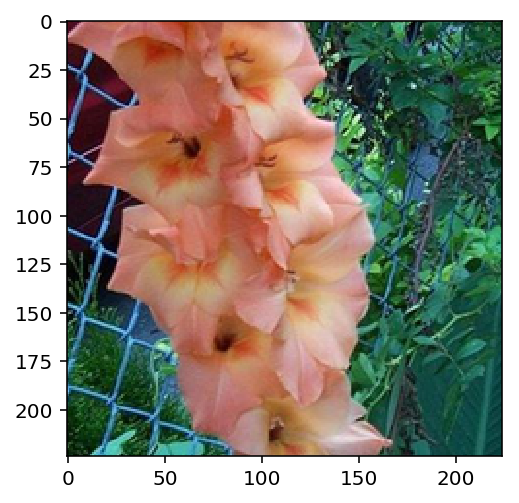

```python
# Test image
image_path = train_dir + '/43/image_02347.jpg'
test_im = process_image(image_path)
imshow(test_im);
```

## Class Prediction

I'll write a function that predicts the top 5 most probable classes with my model. I'll calculate the class probabilities then find the $K$ largest values.

This function takes a path to an image and a model checkpoint, then returns the probabilities and classes.

```
probs, classes = predict(image_path, model)
print(probs)
print(classes)
> [ 0.01558163  0.01541934  0.01452626  0.01443549  0.01407339]
> ['70', '3', '45', '62', '55']
```

```python
def predict(image_path, model, topk=5):
    ''' Predict the class (or classes) of an image using a trained deep learning model.
    '''
    # Implement the code to predict the class from an image file
    # Get processed image
    np_image = process_image(image_path)

    # Convert numpy array to tensor
    image = torch.from_numpy(np_image).type(torch.FloatTensor)
    image = image.unsqueeze (dim=0)

    # Use model to predict
    model.eval()
    with torch.no_grad():
        log_probs = model(image)

    probs = torch.exp(log_probs)
    probs, indices = probs.topk(topk, dim=1)

    # Convert probs, indices to list
    probs, indices = probs.tolist()[0], indices.tolist()[0]

    # Invert class_to_idx to idx_to_class
    class_to_idx = model.class_to_idx

    idx_to_class = {i: class_ for class_, i in class_to_idx.items()}

    # Convert index to class
    classes = []
    for i in indices:
        classes.append(idx_to_class[i])

    return probs, classes
```

```python
probs, classes = predict(image_path, model)
print(probs)
print(classes)
```

```
[0.9995689392089844, 0.00011440785601735115, 8.617586718173698e-05, 3.996154191554524e-05, 3.736633880180307e-05]
['43', '93', '85', '90', '68']
```

## Sanity Checking

I'll check the prediction made by the trained model to make sure it makes sense. I'll use `matplotlib` to plot the probabilities for the top 5 classes as a bar graph, along with the input image. It should look like this:

[figure not shown]

I'll convert from the class integer encoding to actual flower names with `cat_to_name.json`. To show a PyTorch tensor as an image, I'll use the `imshow` function defined above.

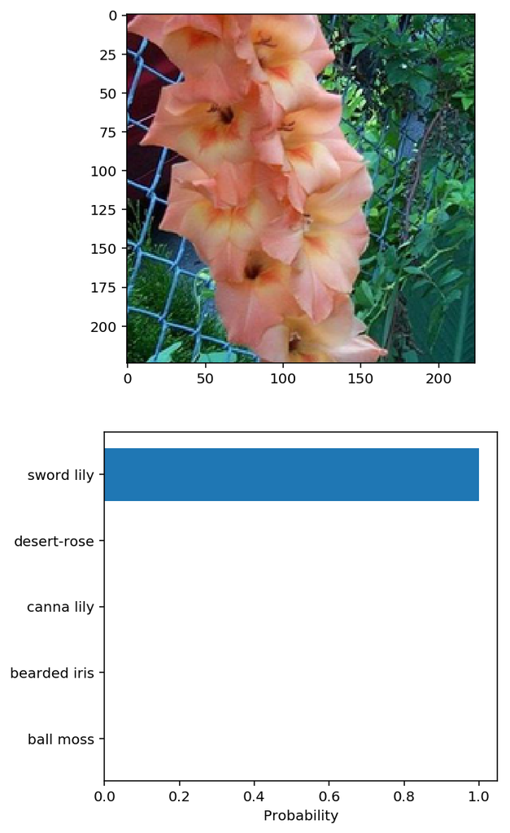

```python
# Display an image along with the top 5 classes
probs, classes = predict(image_path, model)

names = []
for class_ in classes:
    names.append(cat_to_name[class_])

plt.figure(figsize=(5, 10))

# Show image
ax = plt.subplot(2,1,1)
test_im = process_image(image_path)
imshow(test_im, ax, title=names[0])

# Plot probabilities
ax = plt.subplot(2,1,2)
plt.barh(names, probs)
plt.xlabel('Probability')
plt.show()
```